# Health & Economic Impact of Storm Events from early 1950 through November 2011

## Synopsis

In this reprot we aim to describe the health impact of storm events between 1950 and Novermber 2011. Our overall hypothesis is that tornadic events have the highest impact to human health, as measured by injuries and fatalities and that floods have the highest financial damage as measured by crop and property damage.

## Load required libraries for data processing and visualization

```r
library("ggplot2")
library("reshape2")
library("knitr")
library("grid")
library("gridExtra")
```

# Data Processing

The data for this assignment come in the form of a comma-separated-value file compressed via the bzip2 algorithm to reduce its size.  
It is sourced from the Coursera site.

```r
#Download file and decompress
url <- "https://d396qusza40orc.cloudfront.net/repdata%2Fdata%2FStormData.csv.bz2"
file <- basename(url)
download.file(url, file, method="curl")
fcon <- bzfile(file, open="r")
#Read CSV file
stormData <-read.csv(fcon, stringsAsFactors=FALSE)
close(fcon)
```

## Categorize and process the data

Only relevant columns are retained for purposes of either data processing or analysis.

The columns retained for filtering are: STATE (we then filter on only US states, removing properties and other non-US State date).

The columns retained for health analysis are: EVTYPE, FATALITIES, and INJURIES. We later use EVTYPE to create categories of event types to display events. FATALITIES and INJURIES form the basis of the data we would analyze for Health Incidents.

The columns retained for economic analysis are: EVTYPE, PROPDMG, CROPDMG, PROPDMGEXP, and CROPDMGEXP. We later use EVTYPE to create categories of event types to display events. PROPDMG and CROPDMG are base financial data points, and PROPDMGEXP alogn with CROPDMGEXP are interpreted later in data processing to get the correct financial impact figures.

```r
#Keep relevant columns
stormData <- stormData[, c("STATE", "EVTYPE","FATALITIES", "INJURIES", "PROPDMG",
        "PROPDMGEXP", "CROPDMG", "CROPDMGEXP")]
#Remove non US-states such as PR and ST in the data
stormData <- stormData[(stormData$STATE %in% c(state.abb, "DC")), ]

#Convert Property Damanage and Crop Damage columns to characters
stormData$PROPDMGEXP <- as.character(stormData$PROPDMGEXP)
stormData$CROPDMGEXP <- as.character(stormData$CROPDMGEXP)

#Lowercase EVTYPE
stormData$EVTYPE <- tolower(stormData$EVTYPE)
#Remove non-pertinent Weather events (no human, property, or crop damage)
stormData <- stormData[!(stormData$FATALITIES == 0 & stormData$INJURIES == 0 &
        stormData$PROPDMG == 0 & stormData$CROPDMG == 0),]

#Categorize the events from least specific to most
stormData[grepl("turbulence|apache|urban|normal|hyperthermia|record temperatures|
        other|dam|southeast|beach|drowning|none|severe|\\?|mild|excessive|record",
        stormData$EVTYPE), "Category"] <- "Other Events"
stormData[grepl("dry|drought", stormData$EVTYPE), "Category"] <- "Very Dry/Drought"
stormData[grepl("marine|rough|southeast|seiche|stream|heavy seas|wave",
        stormData$EVTYPE), "Category"] <- "Sea/Lake/River Events"
stormData[grepl("summary|metro", stormData$EVTYPE), "Category"] <-
        "Summary of Date"
stormData[grepl("warm|heat|hot|high|warmth", stormData$EVTYPE), "Category"] <-
        "Heat Events"
stormData[grepl("heavy mix|snow|sleet|wintry|winter|cold|cool|freezing|blizzard|
        freeze|low", stormData$EVTYPE), "Category"] <-
        "Cold/Snow/Winter Weather/Blizzard"
stormData[grepl("rainfall|rain|precip|precipatation|precipitation|wet",
        stormData$EVTYPE), "Category"] <- "Rain & Percipatation"
stormData[grepl("fog", stormData$EVTYPE), "Category"] <- "Fog"
stormData[grepl("cloud", stormData$EVTYPE), "Category"] <- "Cloud Related Events"
stormData[grepl("dust", stormData$EVTYPE), "Category"] <- "Dust Related Events"
stormData[grepl("floodin|stream fld|flood|rapidly|flash", stormData$EVTYPE),
        "Category"] <- "Flood"
stormData[grepl("torndao|tornado|funnel|spout|gustnado", stormData$EVTYPE),
        "Category"] <- "Tornado/Gustnado/Funnel Cloud/Waterspout"
stormData[grepl("avalance|avalanche", stormData$EVTYPE), "Category"] <- "Avalanche"
stormData[grepl("coastalstorm|coastal storm", stormData$EVTYPE), "Category"] <-
        "Coastal Storm"
stormData[grepl("thunderstorm|tstm|thunderstormw|lightning|lighting|ligntning",
        stormData$EVTYPE), "Category"] <- "Thunderstorms/Lightning"
stormData[grepl("glaze|frost|ice|icy", stormData$EVTYPE), "Category"] <-
        "Ice Events"
stormData[grepl("wind|burst", stormData$EVTYPE), "Category"] <-
        "Wind, Microbursts, and Downburst Events"
stormData[grepl("hail", stormData$EVTYPE), "Category"] <- "Hail Events"
stormData[grepl("hurricane", stormData$EVTYPE), "Category"] <- "Hurricanes"
stormData[grepl("current|tide|surf|surge", stormData$EVTYPE), "Category"] <-
        "Currents, Surfs, and Tides"
stormData[grepl("fires|wildfire|fire|smoke", stormData$EVTYPE), "Category"] <-
        "Fires/Smoke"
stormData[grepl("mud|rock|mudslides|landslide|landslump|erosion", stormData$EVTYPE),
          "Category"] <- "Rock/Mud/Landslides & Erosion"
stormData[grepl("tropical storm|depression", stormData$EVTYPE), "Category"] <-
        "Tropical Storms/Depressions"
stormData[grepl("tsunami", stormData$EVTYPE), "Category"] <- "Tsunami"
```

Creat a stormHealth specific data set that aggregate the events by category that relate to fatalities and injuries, while removing all data from this data frame that has 0 of both types. We then create a data frame that is ready for plotting with the rolled up categories and the health event types.

```r
stormHealth <- aggregate(cbind(FATALITIES, INJURIES) ~ Category, sum, data =
        stormData)
stormHealth <- stormHealth[!(stormHealth$FATALITIES == 0 &
        stormHealth$INJURIES == 0),]
#Melt data by category to allow for an easy barplot
meltStormHealth <- melt(stormHealth, id="Category", variable.name="Health_Type",
        value.name="Number_Of_Incidents")
```

As a last step for the health data, we create a sorted table for later display to simply show the same data in table format.

```r
#Create two data frames, fatalities and injuries sorted by the highest counts at the top
meltFatalities <- meltStormHealth[meltStormHealth$Health_Type == "FATALITIES",]
meltFatalities <- meltFatalities[order(meltFatalities$Number_Of_Incidents, decreasing=TRUE),]

#Start new data frame with just number of incidnets and make categories the rowname
fatalities <- data.frame(meltFatalities$Number_Of_Incidents)
rownames(fatalities) <- meltFatalities$Category
colnames(fatalities) <- "Number of Fatalities"

#Start creating melted Injuries focued data frame
meltInjuries <- meltStormHealth[meltStormHealth$Health_Type == "INJURIES",]
meltInjuries <- meltInjuries[order(meltInjuries$Number_Of_Incidents, decreasing=TRUE),]

#Start new data frame with just number of incidnets and make categories the rowname
injuries <- data.frame(meltInjuries$Number_Of_Incidents)
rownames(fatalities) <- meltInjuries$Category
colnames(injuries) <- "Number of Injuries"
```

To process the data appropriately, it’s important that we convert the PROPDMGEXP and CROPDMGEXP columns. Based on the data and the write up, it is assumed that the EXP columns are either numbers representing the number of zeros to add to the damage estimate or letter codes. For the letter codes:

h and H = 100 K and K = 1000 m and M = 1,000,000 b and B = 1,000,000,000

All other characters are assumed to be mistakes and therefore PROPDMG and CROPDMG are multiplies by 1.

```r
#Remove data with 0 Prop and Crop Damage
stormEcon <- stormData[!(stormData$PROPDMG == 0 & stormData$CROPDMG ==0),]
#Convert PROPDMGEXP column to $ multiplier
stormEcon[stormEcon$PROPDMGEXP == "" | stormEcon$PROPDMGEXP == "-" | stormEcon$PROPDMGEXP == "+" | stormEcon$PROPDMGEXP == "?" | stormEcon$PROPDMGEXP == "0", "PROPDMGEXP"] <- 1
stormEcon[stormEcon$PROPDMGEXP == "2" | stormEcon$PROPDMGEXP == "h" | stormEcon$PROPDMGEXP == "H", "PROPDMGEXP"] <- 100
stormEcon[stormEcon$PROPDMGEXP == "3" | stormEcon$PROPDMGEXP == "k" | stormEcon$PROPDMGEXP == "K", "PROPDMGEXP"] <- 1000
stormEcon[stormEcon$PROPDMGEXP == "4", "PROPDMGEXP"] <- 10000
stormEcon[stormEcon$PROPDMGEXP == "5", "PROPDMGEXP"] <- 100000
stormEcon[stormEcon$PROPDMGEXP == "6" | stormEcon$PROPDMGEXP == "m" | stormEcon$PROPDMGEXP == "M", "PROPDMGEXP"] <- 1e+06
stormEcon[stormEcon$PROPDMGEXP == "7", "PROPDMGEXP"] <- 1e+07
stormEcon[stormEcon$PROPDMGEXP == "8", "PROPDMGEXP"] <- 1e+08
stormEcon[stormEcon$PROPDMGEXP == "b" | stormEcon$PROPDMGEXP == "B", "PROPDMGEXP"] <- 1e+09
#Convert CROPDMGEXP column to $ multiplier
stormEcon[stormEcon$CROPDMGEXP == "" | stormEcon$CROPDMGEXP == "?" | stormEcon$CROPDMGEXP == "0", "CROPDMGEXP"] <- 1
stormEcon[stormEcon$CROPDMGEXP == "3" | stormEcon$CROPDMGEXP == "k" | stormEcon$CROPDMGEXP == "K", "CROPDMGEXP"] <- 1000
stormEcon[stormEcon$CROPDMGEXP == "6" | stormEcon$CROPDMGEXP == "m" | stormEcon$CROPDMGEXP == "M", "CROPDMGEXP"] <- 1e+06
stormEcon[stormEcon$CROPDMGEXP == "b" | stormEcon$CROPDMGEXP == "B", "CROPDMGEXP"] <- 1e+09
#Convert PROPDMGEXP and CROPDMGEXP to numeric
stormEcon$PROPDMGEXP <- as.numeric(stormEcon$PROPDMGEXP)
stormEcon$CROPDMGEXP <- as.numeric(stormEcon$CROPDMGEXP)
#Multipy to get true property and crop damage
stormEcon$CROPDMG <- stormEcon$CROPDMGEXP * stormEcon$CROPDMG
stormEcon$PROPDMG <- stormEcon$PROPDMGEXP * stormEcon$PROPDMG
```

We then take the work above and prep the data to be plotted

```r
stormEconAgg <- aggregate(cbind(PROPDMG, CROPDMG) ~ Category, sum, data =
        stormEcon)
#Create a Total Damage column
stormEconAgg$Total_Damage <- stormEconAgg$PROPDMG + stormEconAgg$CROPDMG
colnames(stormEconAgg) <- c("Category", "Property_Damage", "Crop_Damage", "Total_Damage")
```

# Results

## Across the United States, which types of events are most harmful with respect to population health?

Given the barplot below, torandic events are clearly most harmful to population health.

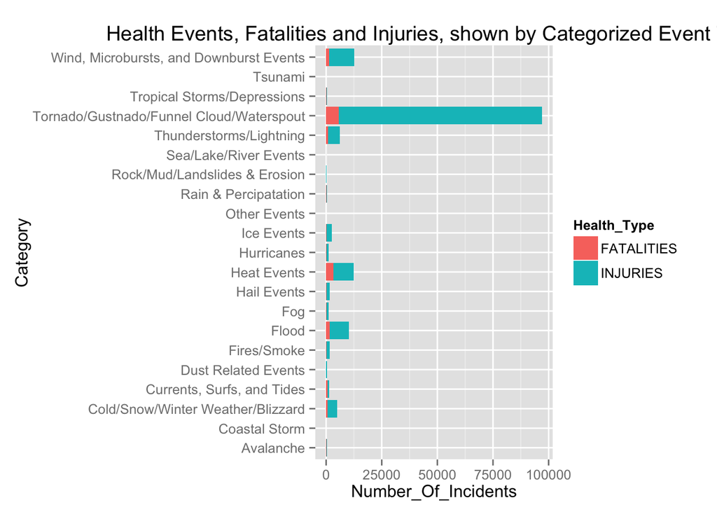

```r
qplot(x=Category, y=Number_Of_Incidents, fill=Health_Type, data=meltStormHealth,
        geom="bar", stat="identity") +
        ggtitle("Health Events, Fatalities and Injuries, shown by Categorized Event Type") + coord_flip()
```

As shown in the table below, see the highest number of incidents by type, it continues to show Tornados as the deadliest category of events.

```r
#output the tables in html
t1 = kable(fatalities, format='html', output = FALSE)
t2 = kable(injuries, format='html', output = FALSE)
cat(c('<table><tr valign="top"><td>', t1, '</td><td>', t2, '</td><tr></table>'), sep = '')
```

|  | Number of Fatalities |
| --- | --- |
| Tornado/Gustnado/Funnel Cloud/Waterspout | 5639 |
| Wind, Microbursts, and Downburst Events | 3184 |
| Heat Events | 1504 |
| Flood | 1385 |
| Thunderstorms/Lightning | 808 |
| Cold/Snow/Winter Weather/Blizzard | 759 |
| Ice Events | 678 |
| Fires/Smoke | 225 |
| Hail Events | 115 |
| Fog | 113 |
| Hurricanes | 90 |
| Currents, Surfs, and Tides | 82 |
| Dust Related Events | 81 |
| Tropical Storms/Depressions | 59 |
| Rain & Percipatation | 45 |
| Avalanche | 41 |
| Rock/Mud/Landslides & Erosion | 24 |
| Sea/Lake/River Events | 19 |
| Coastal Storm | 4 |
| Other Events | 2 |
| Tsunami | 1 |

| Number of Injuries |
| --- |
| 91438 |
| 11358 |
| 9247 |
| 8665 |
| 5265 |
| 4160 |
| 2416 |
| 1607 |
| 1465 |
| 1077 |
| 973 |
| 736 |
| 483 |
| 381 |
| 313 |
| 171 |
| 56 |
| 18 |
| 2 |
| 0 |
| 0 |

## Across the United States, which types of events have the greatest economic consequences?

Floods have the most damage, as shown by the plot below

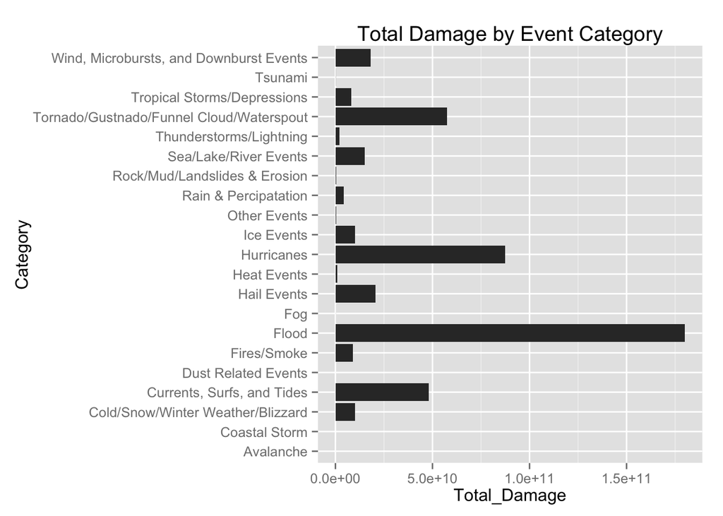

```r
#Show total Damage barplot by Category
qplot(x=Category, y=Total_Damage, data=stormEconAgg, geom="bar", stat="identity") + ggtitle("Total Damage by Event Category") + coord_flip()
```